# Analyses of GSE171792

## Volcano Plot with Gene Length

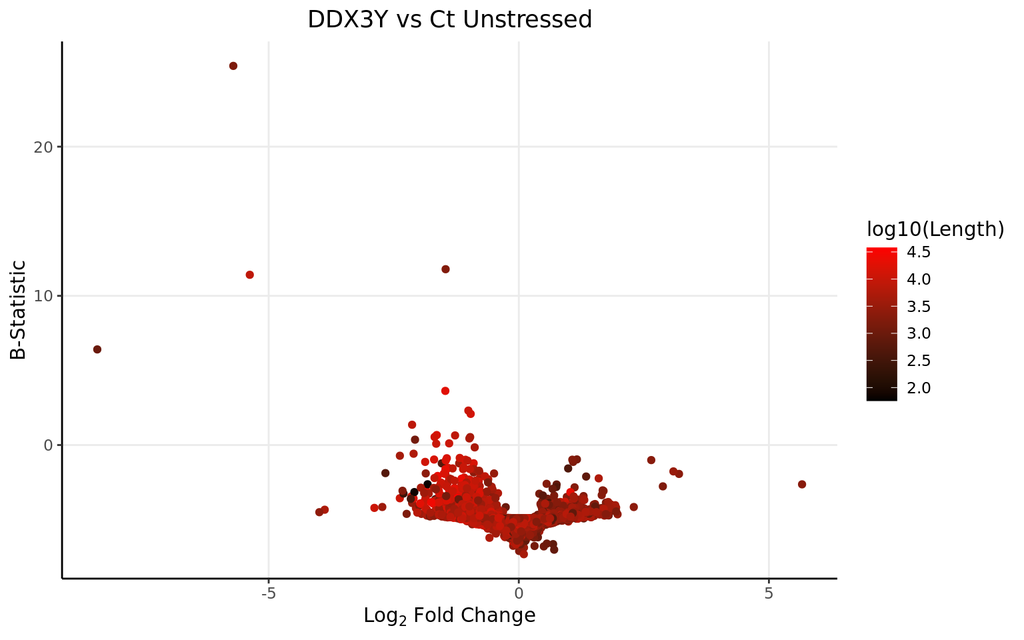

```r
DEGenes_SGY.CTY$Gene <- row.names(DEGenes_SGY.CTY)
colnames(genelength) <- c("Length","Gene")
DEGenes_SGY.CTY <- merge(DEGenes_SGY.CTY, genelength, by="Gene")

ggplot(data=DEGenes_SGY.CTY,
                 aes(x=logFC,
                     y=  B)) +
  geom_point(aes(color=log10(Length)))+
  theme_bw() +
  theme(axis.line = element_line(colour = "black"),
        panel.grid.minor = element_blank(),
        panel.border = element_blank(),
        panel.background = element_blank()) +
  ggtitle("DDX3Y vs Ct Unstressed")+ xlab(expression(Log[2] ~ Fold ~ Change)) + ylab("B-Statistic") +
  theme(plot.title = element_text(hjust = 0.5))  +
  scale_colour_gradient(low = "black", high = "red")+ theme(text=element_text(family = "Quicksand"))
```

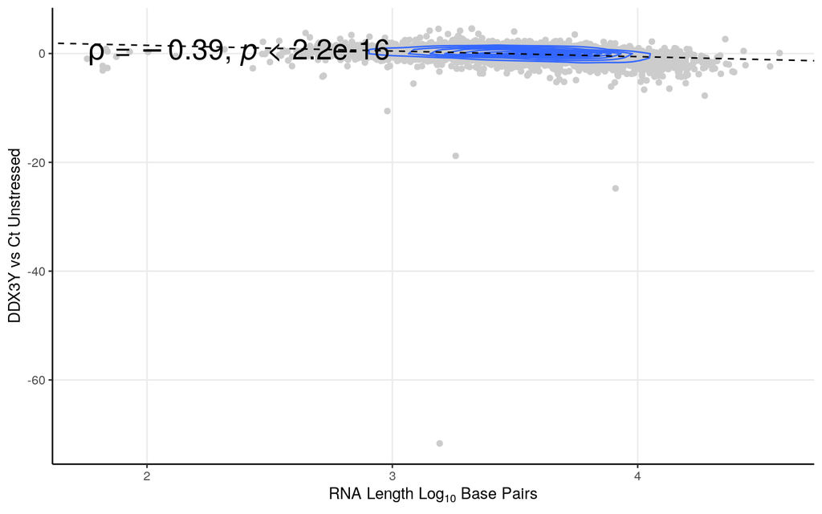

```r
smooth.SG <- lm(t~log10(Length), DEGenes_SGY.CTY)
liner.SG <- rstandard(smooth.SG)
DEGenes_SGY.CTY <-cbind(DEGenes_SGY.CTY, liner.SG)
colnames(DEGenes_SGY.CTY)[9] <- "Residuals"
row.names(DEGenes_SGY.CTY) <- DEGenes_SGY.CTY$Gene
linemarkers <- as.data.frame(DEGenes_SGY.CTY[abs(DEGenes_SGY.CTY$Residuals)>4,])

# Calculate the Spearman correlation coefficient
spearman_corr <- cor(DEGenes_SGY.CTY$t, log10(DEGenes_SGY.CTY$Length), method = "spearman")



ggplot(DEGenes_SGY.CTY, aes(y=t, x=log10(Length))) + geom_point(color="#CCCCCC", alpha=1) +   theme_bw()+ geom_density_2d()+
 ylab("DDX3Y vs Ct Unstressed") + xlab(expression(RNA ~ Length ~ Log[10] ~ Base ~ Pairs)) +
  theme(axis.line = element_line(colour = "black"),
        panel.grid.minor = element_blank(),
        panel.border = element_blank(),
        panel.background = element_blank()) +
  theme(plot.title = element_text(hjust = 0.5))  +
  geom_abline(slope=smooth.SG$coefficients[2], intercept = smooth.SG$coefficients[1], linetype = "dashed")+ stat_cor(method = "spearman", cor.coef.name = "rho",size=7)
```

Negative lenght bias.

## Expression Graphs (Extra QC)

As an added control, lets plot these genes in regard to their expression, and contamination.

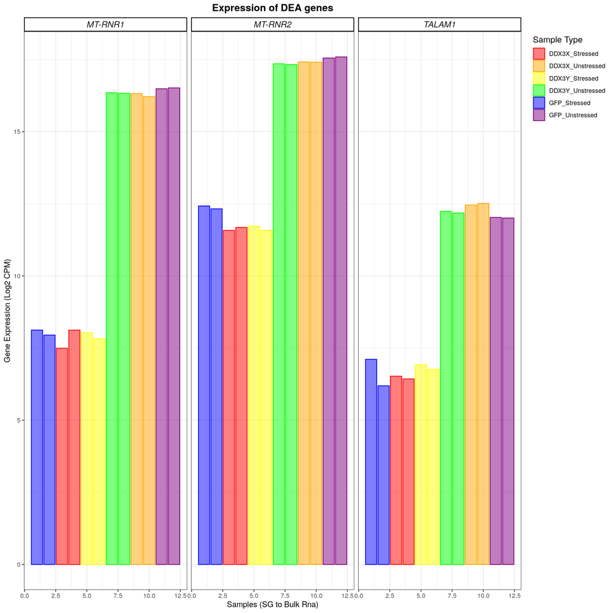

```r
upmarkers <- as.data.frame(DEGenes_SGY.CTY[DEGenes_SGY.CTY$logFC>2 & DEGenes_SGY.CTY$adj.P.Val<0.05,] )
downmarkers <- as.data.frame(DEGenes_SGY.CTY[DEGenes_SGY.CTY$logFC< -2 & DEGenes_SGY.CTY$adj.P.Val<0.05,] )
finagenes <- rbind(upmarkers, downmarkers)

dfforexpression <- dfforpca
samplecodes <- data.frame(samples=row.names(dfforexpression), purity=c(1:12))
sampletype <- data.frame(samples=row.names(dfforexpression), sampletype=fordescriptive)
dfforexpression <- t(dfforexpression)
genesforexp <- dfforexpression[row.names(dfforexpression)%in%row.names(finagenes),]
genesforexp <- reshape2::melt(genesforexp)
colnames(genesforexp) <- c("Gene", "samples", "expression")
genesforexp <- merge(genesforexp, samplecodes, by="samples")
genesforexp <- merge(genesforexp, sampletype, by="samples")
genesforexp <- genesforexp[,-1]
genesforexp[,2] <- as.numeric(genesforexp[,2])
genesforexp[,1] <- as.character(genesforexp[,1])
genesforexp <- genesforexp[order(genesforexp$Gene),]


winnyplot <- ggplot(genesforexp, aes(x=purity, y=expression, fill=sampletype, colour=sampletype)) + geom_bar(position="dodge", stat="identity", alpha=0.5) + facet_wrap(.~ Gene, ncol=5)
winnyplot <- winnyplot + scale_fill_manual(name = "Sample Type", values = c("#FF0000", "#FFA500", "#FFFF00", "#00FF00", "#0000FF", "#800080", "grey")) + scale_colour_manual(name = "Sample Type", values = c("#FF0000", "#FFA500", "#FFFF00", "#00FF00", "#0000FF", "#800080", "grey"))
winnyplot <- winnyplot + theme_bw() + xlab("Samples (SG to Bulk Rna)") + ylab("Gene Expression (Log2 CPM)") + theme(
      strip.text.x = element_text(
        size = 12, face="italic"
        )) +
 theme(
   strip.background = element_rect(
     color="black", fill="#FFFFFF", size=1, linetype="solid"
     )
   ) + theme(
    #legend.position = c(.95, .40),
    legend.justification = c("right", "top"),
    legend.box.just = "right",
    ) + theme(legend.title = element_text(size = 12)) + ggtitle("Expression of DEA genes") + theme(plot.title = element_text(hjust = 0.5, size=14, face="bold"))
winnyplot
```

## GSEA

Now that we have our genes of interest, it would also be interesting to see what are the **altered gene sets** between upregulated and downregulated transcripts from the above comparison. Therefore, lets perform a *Gene Set Enrichment Analysis*

```r
#for all genes
DEGenes_SGY.CTY <- DEGenes_SGY.CTY[order(DEGenes_SGY.CTY[,4]),]
gseatool <- DEGenes_SGY.CTY[,4]
gseatool <- as.data.frame(gseatool)
colnames(gseatool)[1] <- "t"
gseatool[,2] <- DEGenes_SGY.CTY$Gene
colnames(gseatool)[2] <- "Symbol"
gseatool <- gseatool[,c(2,1)]

vectorranks <- gseatool$t
names(vectorranks) <- gseatool$Symbol


#to load our pathways
hallmarks.gs <- msigdbr(species = "Homo sapiens", collection =  "H")

hallmarks.gsets <- hallmarks.gs %>% split(x = .$gene_symbol, f = .$gs_name)

for (set in names(hallmarks.gsets)){
  hallmarks.gsets[[set]] <- toupper(hallmarks.gsets[[set]])
}

hallmarks.res <- fgsea(pathways = hallmarks.gsets,
                       stats = vectorranks)
hallmarks.res.tidy <- hallmarks.res %>%
  as_tibble() %>%
  arrange(desc(NES))

hallmarks.res.tidy %>%
  dplyr::select(-leadingEdge, -ES) %>%
  arrange(padj)
```

```
## # A tibble: 50 × 6
##    pathway                                pval   padj log2err   NES  size
##    <chr>                                 <dbl>  <dbl>   <dbl> <dbl> <int>
##  1 HALLMARK_P53_PATHWAY               0.000604 0.0302   0.477  1.62   126
##  2 HALLMARK_MYOGENESIS                0.0120   0.0896   0.381  1.59    62
##  3 HALLMARK_TNFA_SIGNALING_VIA_NFKB   0.00972  0.0896   0.381  1.50    96
##  4 HALLMARK_OXIDATIVE_PHOSPHORYLATION 0.00403  0.0896   0.407  1.43   174
##  5 HALLMARK_IL2_STAT5_SIGNALING       0.0125   0.0896   0.381 -1.56    82
##  6 HALLMARK_UV_RESPONSE_DN            0.0121   0.0896   0.381 -1.59    76
##  7 HALLMARK_ANDROGEN_RESPONSE         0.0110   0.0896   0.381 -1.72    72
##  8 HALLMARK_MITOTIC_SPINDLE           0.0243   0.152    0.352 -1.54   164
##  9 HALLMARK_PROTEIN_SECRETION         0.0403   0.224    0.257 -1.48    76
## 10 HALLMARK_HYPOXIA                   0.0577   0.244    0.322  1.27   105
## # ℹ 40 more rows
```

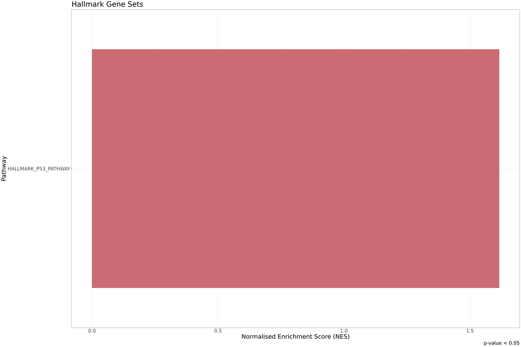

```r
hallmark.sg.t <- hallmarks.res.tidy[,c(1,6)]
hallmark.sg.t <- as.data.frame(hallmark.sg.t)

#this small part is generic
thresh <- 0.05

#this one is no longer generic
data_to_plot <- hallmarks.res.tidy %>% filter(padj < thresh)

statvec <- c()
for (i in 1:nrow(data_to_plot)){
  if (data_to_plot[i,6] > 0){
    status <- "Upregulated"
  }
 else {
   status <- "Downregulated"
 }
statvec <- c(statvec, status)
}

data_to_plot$Status <- statvec

##-----HALMARK-----
gsea_plot_hall <- ggplot(data_to_plot, aes(reorder(pathway, NES), NES)) +
  geom_col(aes(fill= Status), alpha=0.75) + scale_fill_manual(values = c("#53A2BE","#BA3B46"), name = "Regulation Status", labels = c("Downregulated", "Upregulated"), breaks = c("Downregulated", "Upregulated")) +
  coord_flip() +
  labs(x="Pathway", y="Normalised Enrichment Score (NES)",
       title= "Hallmark Gene Sets",
       caption = paste0("p-value < ", thresh)) + theme(plot.title = element_text(hjust = 1)) +
  theme_bw() + theme(text=element_text(family = "Quicksand")) + theme(legend.position = "none")

gsea_plot_hall+
  theme(text=element_text(size=25,  family="Arial MS"))
```

# DDX3Y vs DDX3X

## Volcano Plot

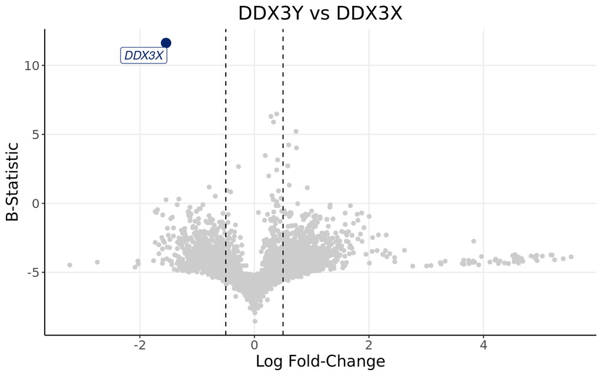

```r
ndegs <- 10
upmarkers <- as.data.frame(DEGenes_SGY.SGX[DEGenes_SGY.SGX$logFC>1 & DEGenes_SGY.SGX$adj.P.Val<0.05,] )
downmarkers <- as.data.frame(DEGenes_SGY.SGX[DEGenes_SGY.SGX$logFC< -1 & DEGenes_SGY.SGX$adj.P.Val<0.05,] )

ggplot(data=DEGenes_SGY.SGX,
                 aes(x=logFC,
                     y=  B)) +
  geom_point(color="#CCCCCC")+ geom_vline(xintercept = -0.5, linetype="dashed")+geom_vline(xintercept = 0.5, linetype="dashed")+
  theme_bw() + ylab("B-Statistic")+xlab("Log Fold-Change")+
  theme(axis.line = element_line(colour = "black"),
        panel.grid.minor = element_blank(),
        panel.border = element_blank(),
        panel.background = element_blank()) +
  ggtitle("DDX3Y vs DDX3X")+
  theme(plot.title = element_text(hjust = 0.5), plot.subtitle = element_text(hjust = 0.5)) +
  geom_point(data=upmarkers, aes(x=logFC, y=  B), color="#A10702",size=4)+
  geom_point(data=downmarkers, aes(x=logFC, y=  B), color="#03256C",size=4)+
  geom_label_repel(upmarkers[1:ndegs,] , mapping=aes(label=row.names(upmarkers)[1:ndegs]),size=4,point.padding=-0.5, color="#A10702",max.overlaps = 20, fontface="italic")+
  geom_label_repel(downmarkers[1:ndegs,] , mapping=aes(label=row.names(downmarkers)[1:ndegs]),size=4,point.padding=-0.5, color="#03256C",max.overlaps = 20, fontface="italic")+
  theme(text=element_text(size=15,  family="Arial MS"))
```

Even the volcano shape is a bit weird. Not many differences.

## Volcano Plot with Gene Length

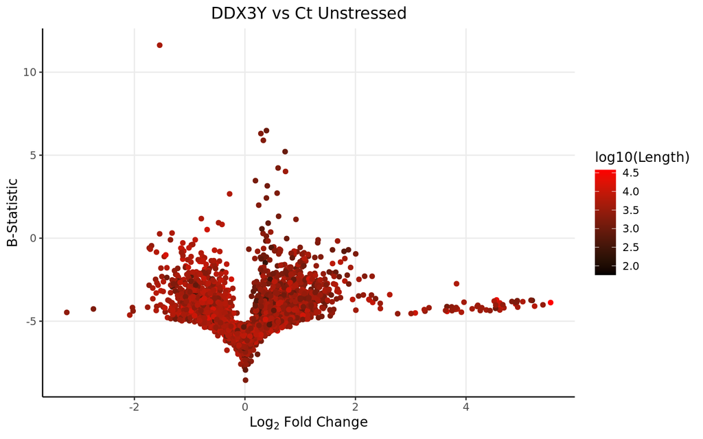

```r
DEGenes_SGY.SGX$Gene <- row.names(DEGenes_SGY.SGX)
colnames(genelength) <- c("Length","Gene")
DEGenes_SGY.SGX <- merge(DEGenes_SGY.SGX, genelength, by="Gene")

ggplot(data=DEGenes_SGY.SGX,
                 aes(x=logFC,
                     y=  B)) +
  geom_point(aes(color=log10(Length)))+
  theme_bw() +
  theme(axis.line = element_line(colour = "black"),
        panel.grid.minor = element_blank(),
        panel.border = element_blank(),
        panel.background = element_blank()) +
  ggtitle("DDX3Y vs Ct Unstressed")+ xlab(expression(Log[2] ~ Fold ~ Change)) + ylab("B-Statistic") +
  theme(plot.title = element_text(hjust = 0.5))  +
  scale_colour_gradient(low = "black", high = "red")+ theme(text=element_text(family = "Quicksand"))
```

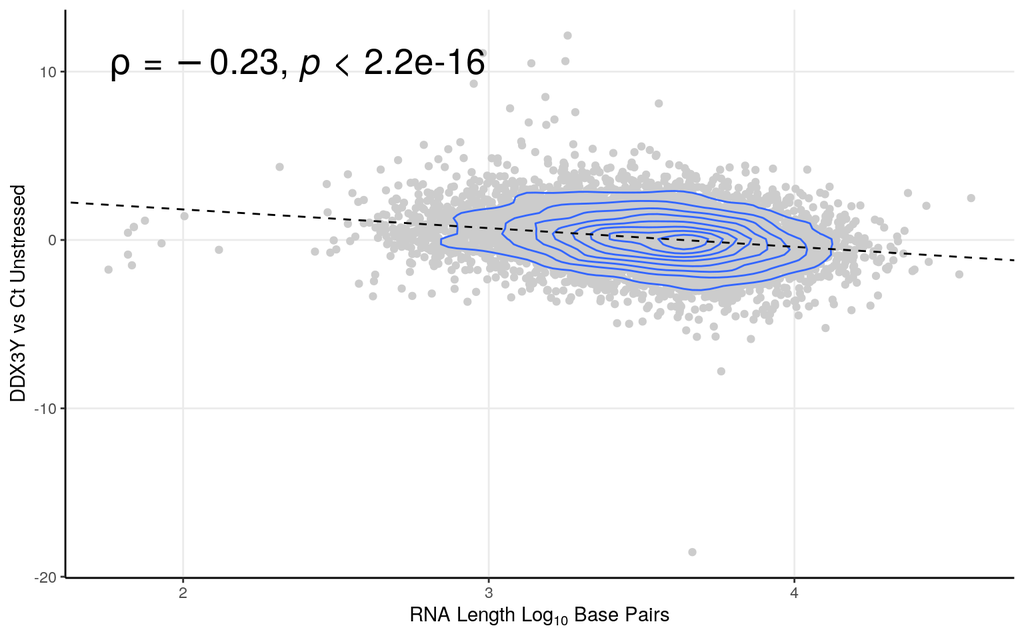

```r
smooth.SG <- lm(t~log10(Length), DEGenes_SGY.SGX)
liner.SG <- rstandard(smooth.SG)
DEGenes_SGY.SGX <-cbind(DEGenes_SGY.SGX, liner.SG)
colnames(DEGenes_SGY.SGX)[9] <- "Residuals"
row.names(DEGenes_SGY.SGX) <- DEGenes_SGY.SGX$Gene
linemarkers <- as.data.frame(DEGenes_SGY.SGX[abs(DEGenes_SGY.SGX$Residuals)>4,])

# Calculate the Spearman correlation coefficient
spearman_corr <- cor(DEGenes_SGY.SGX$t, log10(DEGenes_SGY.SGX$Length), method = "spearman")



ggplot(DEGenes_SGY.SGX, aes(y=t, x=log10(Length))) + geom_point(color="#CCCCCC", alpha=1) +   theme_bw()+ geom_density_2d()+
 ylab("DDX3Y vs Ct Unstressed") + xlab(expression(RNA ~ Length ~ Log[10] ~ Base ~ Pairs)) +
  theme(axis.line = element_line(colour = "black"),
        panel.grid.minor = element_blank(),
        panel.border = element_blank(),
        panel.background = element_blank()) +
  theme(plot.title = element_text(hjust = 0.5))  +
  geom_abline(slope=smooth.SG$coefficients[2], intercept = smooth.SG$coefficients[1], linetype = "dashed")+ stat_cor(method = "spearman", cor.coef.name = "rho",size=7)
```

Negative lenght bias.

# SG (With Both GFP Samples)

Now we must perform linear model fitting. Once more, we will have 4, one for each matrix we previously designed.

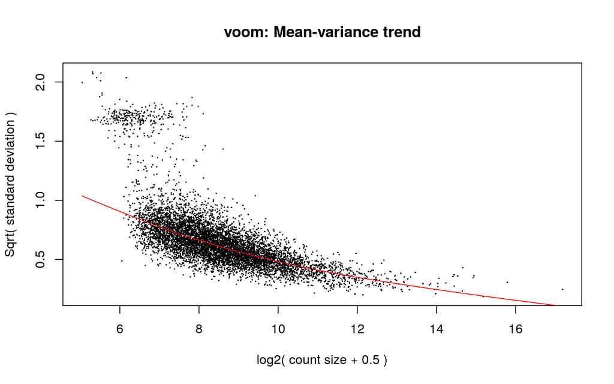

```r
#Let us prepare metadata to add to our samples
forstress <- c("Stress", "Stress", "Stress", "Stress", "Stress", "Stress", "CT", "CT", "CT", "CT", "CT", "CT")

forgenome <- c("GFP", "GFP", "DDX3X","DDX3X", "DDX3Y", "DDX3Y", "DDX3Y", "DDX3Y", "DDX3X", "DDX3X", "GFP", "GFP")

forsg <- c("NO","NO", "YES", "YES", "YES", "YES", "NO", "NO", "NO", "NO", "NO", "NO")

#The object with full description
mm <- model.matrix(~0+forstress+forgenome+forsg)

y <- voom(D0, mm, plot = T)
```

```r
fitted_y <- lmFit(y, mm)

#Just to see if everything is ok

head(coef(fitted_y))
```

```
##       forstressCT forstressStress forgenomeDDX3Y forgenomeGFP    forsgYES
## AAAS     5.867367        6.384137      0.3798866    0.4567165 -0.41641682
## AACS     3.994478        4.508411     -0.2030775    0.3798828  0.36336860
## AAGAB    6.768511        6.890047     -0.6462679   -0.4822135 -0.04741485
## AAK1     6.713519        4.106546     -0.3456144    0.2756784  1.92161045
## AAMP     6.055174        6.156844     -0.1576063    0.2201809  0.31486679
## AAR2     5.759297        5.832322      0.1669125    0.2899304 -0.03597585
```

```r
#Correction for multiple testing
tmp <- eBayes(fitted_y)
```

Lets move on to the main analyses.

```r
#TOP Tables
top <- topTable(tmp,5,sort.by = "logFC", n=Inf)


#DEGenes

DEGenes <- top
```

## Volcano Plot

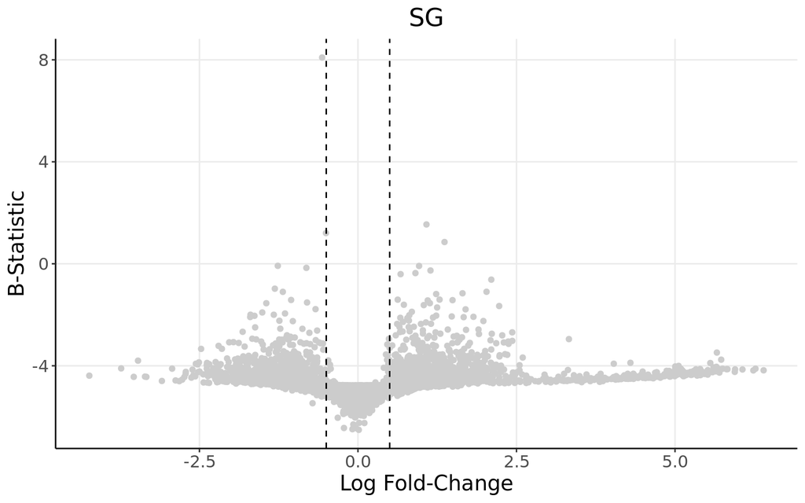

```r
ndegs <- 10
upmarkers <- as.data.frame(DEGenes[DEGenes$logFC>1 & DEGenes$adj.P.Val<0.05,] )
downmarkers <- as.data.frame(DEGenes[DEGenes$logFC< -1 & DEGenes$adj.P.Val<0.05,] )

ggplot(data=DEGenes,
                 aes(x=logFC,
                     y=  B)) +
  geom_point(color="#CCCCCC")+ geom_vline(xintercept = -0.5, linetype="dashed")+geom_vline(xintercept = 0.5, linetype="dashed")+
  theme_bw() + ylab("B-Statistic")+xlab("Log Fold-Change")+
  theme(axis.line = element_line(colour = "black"),
        panel.grid.minor = element_blank(),
        panel.border = element_blank(),
        panel.background = element_blank()) +
  ggtitle("SG")+
  theme(plot.title = element_text(hjust = 0.5), plot.subtitle = element_text(hjust = 0.5)) +
  geom_point(data=upmarkers, aes(x=logFC, y=  B), color="#A10702",size=4)+
  geom_point(data=downmarkers, aes(x=logFC, y=  B), color="#03256C",size=4)+
  geom_label_repel(upmarkers[1:ndegs,] , mapping=aes(label=row.names(upmarkers)[1:ndegs]),size=4,point.padding=-0.5, color="#A10702",max.overlaps = 20, fontface="italic")+
  geom_label_repel(downmarkers[1:ndegs,] , mapping=aes(label=row.names(downmarkers)[1:ndegs]),size=4,point.padding=-0.5, color="#03256C",max.overlaps = 20, fontface="italic")+
  theme(text=element_text(size=15,  family="Arial MS"))
```

Even the volcano shape is a bit weird

## Volcano Plot with Gene Length

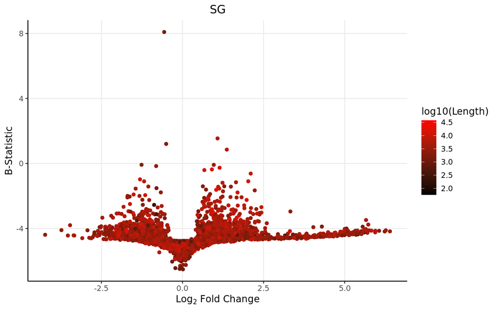

```r
DEGenes$Gene <- row.names(DEGenes)
colnames(genelength) <- c("Length","Gene")
DEGenes <- merge(DEGenes, genelength, by="Gene")

ggplot(data=DEGenes,
                 aes(x=logFC,
                     y=  B)) +
  geom_point(aes(color=log10(Length)))+
  theme_bw() +
  theme(axis.line = element_line(colour = "black"),
        panel.grid.minor = element_blank(),
        panel.border = element_blank(),
        panel.background = element_blank()) +
  ggtitle("SG")+ xlab(expression(Log[2] ~ Fold ~ Change)) + ylab("B-Statistic") +
  theme(plot.title = element_text(hjust = 0.5))  +
  scale_colour_gradient(low = "black", high = "red")+ theme(text=element_text(family = "Quicksand"))
```

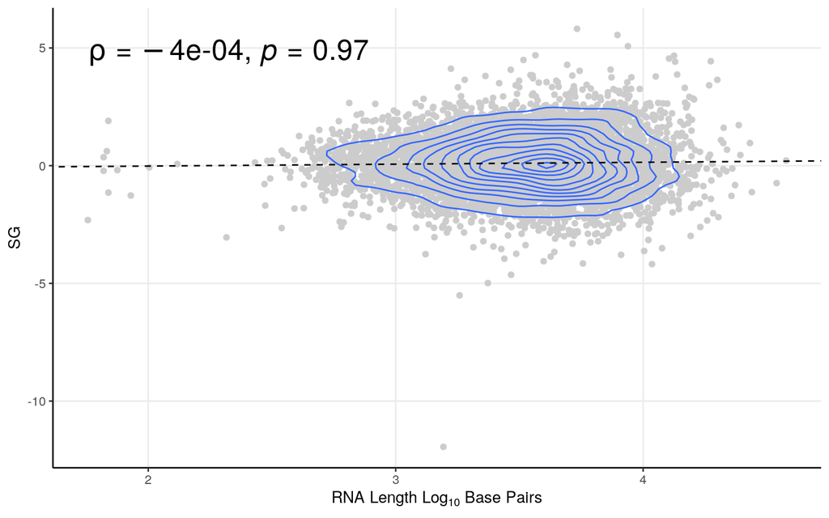

```r
smooth.SG <- lm(t~log10(Length), DEGenes)
liner.SG <- rstandard(smooth.SG)
DEGenes <-cbind(DEGenes, liner.SG)
colnames(DEGenes)[9] <- "Residuals"
row.names(DEGenes) <- DEGenes$Gene
linemarkers <- as.data.frame(DEGenes[abs(DEGenes$Residuals)>4,])

# Calculate the Spearman correlation coefficient
spearman_corr <- cor(DEGenes$t, log10(DEGenes$Length), method = "spearman")



ggplot(DEGenes, aes(y=t, x=log10(Length))) + geom_point(color="#CCCCCC", alpha=1) +   theme_bw()+ geom_density_2d()+
 ylab("SG") + xlab(expression(RNA ~ Length ~ Log[10] ~ Base ~ Pairs)) +
  theme(axis.line = element_line(colour = "black"),
        panel.grid.minor = element_blank(),
        panel.border = element_blank(),
        panel.background = element_blank()) +
  theme(plot.title = element_text(hjust = 0.5))  +
  geom_abline(slope=smooth.SG$coefficients[2], intercept = smooth.SG$coefficients[1], linetype = "dashed")+ stat_cor(method = "spearman", cor.coef.name = "rho",size=7)
```

# SG (With GFP 2)

Now we must perform linear model fitting. Once more, we will have 4, one for each matrix we previously designed.

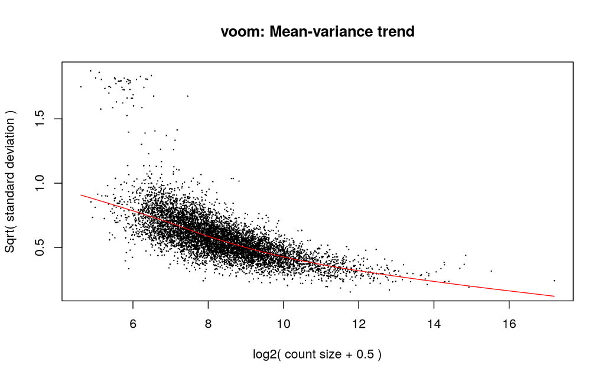

```r
#Let us prepare metadata to add to our samples
forstress <- c("Stress", "Stress", "Stress", "Stress", "Stress", "Stress", "CT", "CT", "CT", "CT", "CT", "CT")[-1]

forgenome <- c("GFP", "GFP", "DDX3X","DDX3X", "DDX3Y", "DDX3Y", "DDX3Y", "DDX3Y", "DDX3X", "DDX3X", "GFP", "GFP")[-1]

forsg <- c("NO","NO", "YES", "YES", "YES", "YES", "NO", "NO", "NO", "NO", "NO", "NO")[-2]

#The object with full description
mm <- model.matrix(~0+forstress+forgenome+forsg)

y <- voom(D0[,-1], mm, plot = T)
```

```r
fitted_y <- lmFit(y, mm)

#Just to see if everything is ok

head(coef(fitted_y))
```

```
##       forstressCT forstressStress forgenomeDDX3Y forgenomeGFP   forsgYES
## AAAS     5.864868        6.508822      0.3823576    0.4592182 -0.5423657
## AACS     3.981131        5.263676     -0.2004569    0.4151472 -0.3941417
## AAGAB    6.765782        6.385644     -0.6434465   -0.4823116  0.4530239
## AAK1     6.713714        5.905044     -0.3463833    0.2746579  0.1237872
## AAMP     6.057365        5.466845     -0.1562976    0.2176158  1.0042960
## AAR2     5.759361        5.438812      0.1686311    0.2748943  0.3550546
```

```r
#Correction for multiple testing
tmp <- eBayes(fitted_y)
```

Lets move on to the main analyses.

```r
#TOP Tables
top <- topTable(tmp,5,sort.by = "logFC", n=Inf)


#DEGenes

DEGenes <- top
```

## Volcano Plot

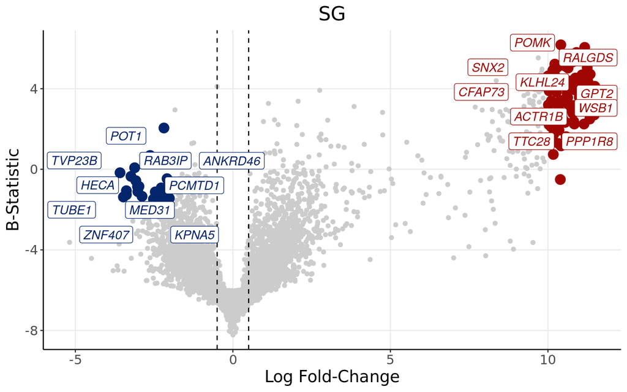

```r
ndegs <- 10
upmarkers <- as.data.frame(DEGenes[DEGenes$logFC>10 & DEGenes$adj.P.Val<0.05,] )
downmarkers <- as.data.frame(DEGenes[DEGenes$logFC< -2 & DEGenes$adj.P.Val<0.05,] )

ggplot(data=DEGenes,
                 aes(x=logFC,
                     y=  B)) +
  geom_point(color="#CCCCCC")+ geom_vline(xintercept = -0.5, linetype="dashed")+geom_vline(xintercept = 0.5, linetype="dashed")+
  theme_bw() + ylab("B-Statistic")+xlab("Log Fold-Change")+
  theme(axis.line = element_line(colour = "black"),
        panel.grid.minor = element_blank(),
        panel.border = element_blank(),
        panel.background = element_blank()) +
  ggtitle("SG")+
  theme(plot.title = element_text(hjust = 0.5), plot.subtitle = element_text(hjust = 0.5)) +
  geom_point(data=upmarkers, aes(x=logFC, y=  B), color="#A10702",size=4)+
  geom_point(data=downmarkers, aes(x=logFC, y=  B), color="#03256C",size=4)+
  geom_label_repel(upmarkers[1:ndegs,] , mapping=aes(label=row.names(upmarkers)[1:ndegs]),size=4,point.padding=-0.5, color="#A10702",max.overlaps = 20, fontface="italic")+
  geom_label_repel(downmarkers[1:ndegs,] , mapping=aes(label=row.names(downmarkers)[1:ndegs]),size=4,point.padding=-0.5, color="#03256C",max.overlaps = 20, fontface="italic")+
  theme(text=element_text(size=15,  family="Arial MS"))
```

Even the volcano shape is a bit weird

## Volcano Plot with Gene Length

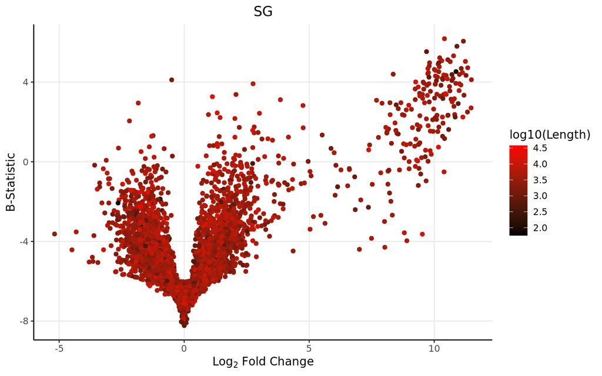

```r
DEGenes$Gene <- row.names(DEGenes)
colnames(genelength) <- c("Length","Gene")
DEGenes <- merge(DEGenes, genelength, by="Gene")

ggplot(data=DEGenes,
                 aes(x=logFC,
                     y=  B)) +
  geom_point(aes(color=log10(Length)))+
  theme_bw() +
  theme(axis.line = element_line(colour = "black"),
        panel.grid.minor = element_blank(),
        panel.border = element_blank(),
        panel.background = element_blank()) +
  ggtitle("SG")+ xlab(expression(Log[2] ~ Fold ~ Change)) + ylab("B-Statistic") +
  theme(plot.title = element_text(hjust = 0.5))  +
  scale_colour_gradient(low = "black", high = "red")+ theme(text=element_text(family = "Quicksand"))
```

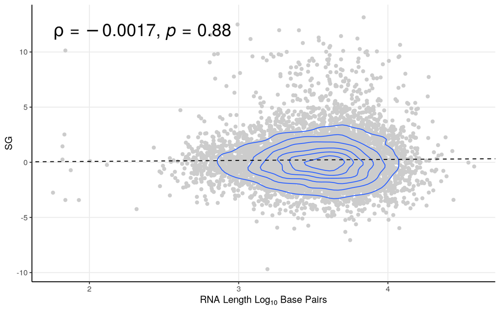

```r
smooth.SG <- lm(t~log10(Length), DEGenes)
liner.SG <- rstandard(smooth.SG)
DEGenes <-cbind(DEGenes, liner.SG)
colnames(DEGenes)[9] <- "Residuals"
row.names(DEGenes) <- DEGenes$Gene
linemarkers <- as.data.frame(DEGenes[abs(DEGenes$Residuals)>4,])

# Calculate the Spearman correlation coefficient
spearman_corr <- cor(DEGenes$t, log10(DEGenes$Length), method = "spearman")



ggplot(DEGenes, aes(y=t, x=log10(Length))) + geom_point(color="#CCCCCC", alpha=1) +   theme_bw()+ geom_density_2d()+
 ylab("SG") + xlab(expression(RNA ~ Length ~ Log[10] ~ Base ~ Pairs)) +
  theme(axis.line = element_line(colour = "black"),
        panel.grid.minor = element_blank(),
        panel.border = element_blank(),
        panel.background = element_blank()) +
  theme(plot.title = element_text(hjust = 0.5))  +
  geom_abline(slope=smooth.SG$coefficients[2], intercept = smooth.SG$coefficients[1], linetype = "dashed")+ stat_cor(method = "spearman", cor.coef.name = "rho",size=7)
```

No lenght bias

## Expression Graphs (Extra QC)

As an added control, lets plot these genes in regard to their expression, and contamination.

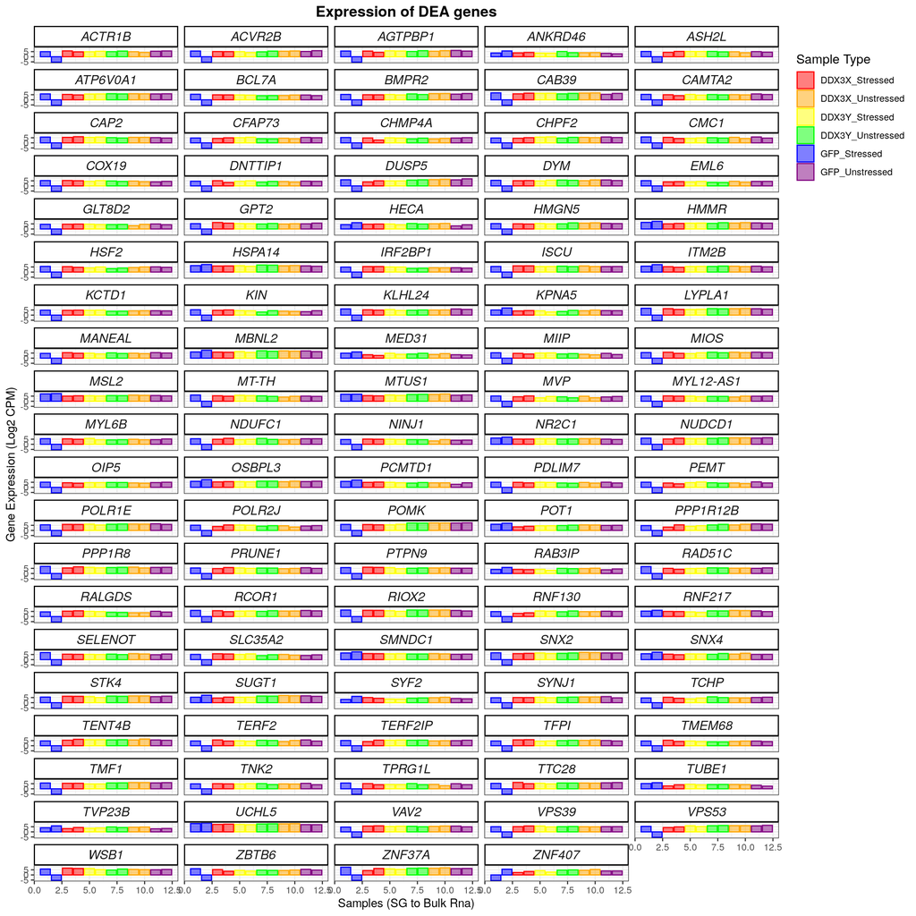

```r
upmarkers <- as.data.frame(DEGenes[DEGenes$logFC>10 & DEGenes$adj.P.Val<0.05,] )
downmarkers <- as.data.frame(DEGenes[DEGenes$logFC< -2 & DEGenes$adj.P.Val<0.05,] )
finagenes <- rbind(upmarkers, downmarkers)

dfforexpression <- dfforpca
samplecodes <- data.frame(samples=row.names(dfforexpression), purity=c(1:12))
sampletype <- data.frame(samples=row.names(dfforexpression), sampletype=fordescriptive)
dfforexpression <- t(dfforexpression)
genesforexp <- dfforexpression[row.names(dfforexpression)%in%row.names(finagenes),]
genesforexp <- reshape2::melt(genesforexp)
colnames(genesforexp) <- c("Gene", "samples", "expression")
genesforexp <- merge(genesforexp, samplecodes, by="samples")
genesforexp <- merge(genesforexp, sampletype, by="samples")
genesforexp <- genesforexp[,-1]
genesforexp[,2] <- as.numeric(genesforexp[,2])
genesforexp[,1] <- as.character(genesforexp[,1])
genesforexp <- genesforexp[order(genesforexp$Gene),]


winnyplot <- ggplot(genesforexp, aes(x=purity, y=expression, fill=sampletype, colour=sampletype)) + geom_bar(position="dodge", stat="identity", alpha=0.5) + facet_wrap(.~ Gene, ncol=5)
winnyplot <- winnyplot + scale_fill_manual(name = "Sample Type", values = c("#FF0000", "#FFA500", "#FFFF00", "#00FF00", "#0000FF", "#800080", "grey")) + scale_colour_manual(name = "Sample Type", values = c("#FF0000", "#FFA500", "#FFFF00", "#00FF00", "#0000FF", "#800080", "grey"))
winnyplot <- winnyplot + theme_bw() + xlab("Samples (SG to Bulk Rna)") + ylab("Gene Expression (Log2 CPM)") + theme(
      strip.text.x = element_text(
        size = 12, face="italic"
        )) +
 theme(
   strip.background = element_rect(
     color="black", fill="#FFFFFF", size=1, linetype="solid"
     )
   ) + theme(
    #legend.position = c(.95, .40),
    legend.justification = c("right", "top"),
    legend.box.just = "right",
    ) + theme(legend.title = element_text(size = 12)) + ggtitle("Expression of DEA genes") + theme(plot.title = element_text(hjust = 0.5, size=14, face="bold"))
winnyplot
```

## GSEA

Now that we have our genes of interest, it would also be interesting to see what are the **altered gene sets** between upregulated and downregulated transcripts from the above comparison. Therefore, lets perform a *Gene Set Enrichment Analysis*

```r
#for all genes
DEGenes <- DEGenes[order(DEGenes[,4]),]
gseatool <- DEGenes[,4]
gseatool <- as.data.frame(gseatool)
colnames(gseatool)[1] <- "t"
gseatool[,2] <- DEGenes$Gene
colnames(gseatool)[2] <- "Symbol"
gseatool <- gseatool[,c(2,1)]

vectorranks <- gseatool$t
names(vectorranks) <- gseatool$Symbol


#to load our pathways
hallmarks.gs <- msigdbr(species = "Homo sapiens", collection =  "H")

hallmarks.gsets <- hallmarks.gs %>% split(x = .$gene_symbol, f = .$gs_name)

for (set in names(hallmarks.gsets)){
  hallmarks.gsets[[set]] <- toupper(hallmarks.gsets[[set]])
}

hallmarks.res <- fgsea(pathways = hallmarks.gsets,
                       stats = vectorranks)
hallmarks.res.tidy <- hallmarks.res %>%
  as_tibble() %>%
  arrange(desc(NES))

hallmarks.res.tidy %>%
  dplyr::select(-leadingEdge, -ES) %>%
  arrange(padj)
```

```
## # A tibble: 50 × 6
##    pathway                                      pval    padj log2err   NES  size
##    <chr>                                       <dbl>   <dbl>   <dbl> <dbl> <int>
##  1 HALLMARK_MYC_TARGETS_V1                   6.32e-6 3.16e-4   0.611 -1.80   185
##  2 HALLMARK_MYOGENESIS                       2.62e-4 6.54e-3   0.498  1.83    62
##  3 HALLMARK_ANDROGEN_RESPONSE                8.24e-4 1.37e-2   0.477 -1.74    72
##  4 HALLMARK_UV_RESPONSE_DN                   1.25e-3 1.56e-2   0.455  1.72    76
##  5 HALLMARK_APICAL_JUNCTION                  3.96e-3 3.93e-2   0.407  1.70    78
##  6 HALLMARK_EPITHELIAL_MESENCHYMAL_TRANSITI… 5.50e-3 3.93e-2   0.407  1.61    73
##  7 HALLMARK_HYPOXIA                          5.33e-3 3.93e-2   0.407  1.58   105
##  8 HALLMARK_XENOBIOTIC_METABOLISM            7.31e-3 4.57e-2   0.407  1.58    79
##  9 HALLMARK_IL2_STAT5_SIGNALING              3.83e-2 2.13e-1   0.322  1.47    82
## 10 HALLMARK_PANCREAS_BETA_CELLS              4.38e-2 2.19e-1   0.322 -1.56     7
## # ℹ 40 more rows
```

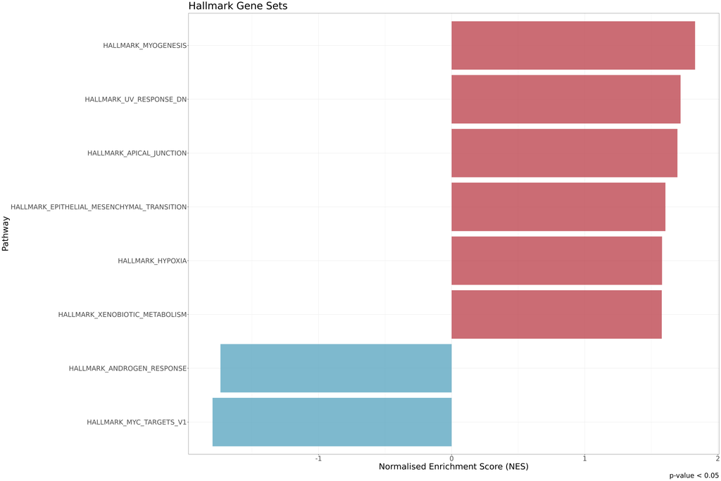

```r
hallmark.sg.t <- hallmarks.res.tidy[,c(1,6)]
hallmark.sg.t <- as.data.frame(hallmark.sg.t)

#this small part is generic
thresh <- 0.05

#this one is no longer generic
data_to_plot <- hallmarks.res.tidy %>% filter(padj < thresh)

statvec <- c()
for (i in 1:nrow(data_to_plot)){
  if (data_to_plot[i,6] > 0){
    status <- "Upregulated"
  }
 else {
   status <- "Downregulated"
 }
statvec <- c(statvec, status)
}

data_to_plot$Status <- statvec

##-----HALMARK-----
gsea_plot_hall <- ggplot(data_to_plot, aes(reorder(pathway, NES), NES)) +
  geom_col(aes(fill= Status), alpha=0.75) + scale_fill_manual(values = c("#53A2BE","#BA3B46"), name = "Regulation Status", labels = c("Downregulated", "Upregulated"), breaks = c("Downregulated", "Upregulated")) +
  coord_flip() +
  labs(x="Pathway", y="Normalised Enrichment Score (NES)",
       title= "Hallmark Gene Sets",
       caption = paste0("p-value < ", thresh)) + theme(plot.title = element_text(hjust = 1)) +
  theme_bw() + theme(text=element_text(family = "Quicksand")) + theme(legend.position = "none")

gsea_plot_hall+
  theme(text=element_text(size=25,  family="Arial MS"))
```

# SG (With GFP 1)

Now we must perform linear model fitting. Once more, we will have 4, one for each matrix we previously designed.

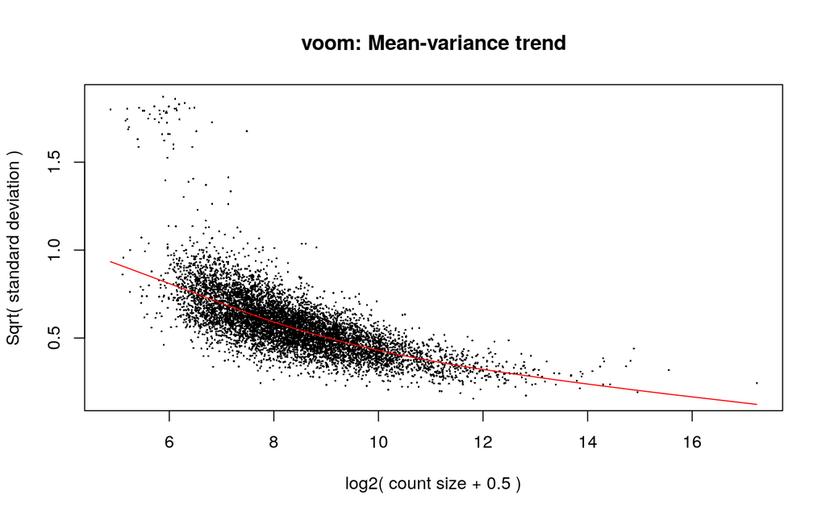

```r
#Let us prepare metadata to add to our samples
forstress <- c("Stress", "Stress", "Stress", "Stress", "Stress", "Stress", "CT", "CT", "CT", "CT", "CT", "CT")[-2]

forgenome <- c("GFP", "GFP", "DDX3X","DDX3X", "DDX3Y", "DDX3Y", "DDX3Y", "DDX3Y", "DDX3X", "DDX3X", "GFP", "GFP")[-2]

forsg <- c("NO","NO", "YES", "YES", "YES", "YES", "NO", "NO", "NO", "NO", "NO", "NO")[-2]

#The object with full description
mm <- model.matrix(~0+forstress+forgenome+forsg)

y <- voom(D0[,-2], mm, plot = T)
```

```r
fitted_y <- lmFit(y, mm)

#Just to see if everything is ok

head(coef(fitted_y))
```

```
##       forstressCT forstressStress forgenomeDDX3Y forgenomeGFP   forsgYES
## AAAS     5.866529        6.277722      0.3827224    0.4575547 -0.3114486
## AACS     3.988487        3.831557     -0.2031528    0.3965686  1.0398865
## AAGAB    6.764146        7.305883     -0.6444042   -0.4783507 -0.4667174
## AAK1     6.713841        2.604379     -0.3466393    0.2722200  3.4245340
## AAMP     6.053832        6.731628     -0.1573238    0.2214569 -0.2600247
## AAR2     5.759036        6.175051      0.1675955    0.2861738 -0.3805298
```

```r
#Correction for multiple testing
tmp <- eBayes(fitted_y)
```

Lets move on to the main analyses.

```r
#TOP Tables
top <- topTable(tmp,5,sort.by = "logFC", n=Inf)


#DEGenes

DEGenes <- top
```

## Volcano Plot

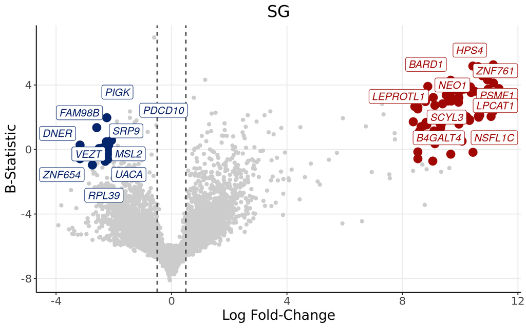

```r
ndegs <- 10
upmarkers <- as.data.frame(DEGenes[DEGenes$logFC>8 & DEGenes$adj.P.Val<0.05,] )
downmarkers <- as.data.frame(DEGenes[DEGenes$logFC< -2 & DEGenes$adj.P.Val<0.05,] )

ggplot(data=DEGenes,
                 aes(x=logFC,
                     y=  B)) +
  geom_point(color="#CCCCCC")+ geom_vline(xintercept = -0.5, linetype="dashed")+geom_vline(xintercept = 0.5, linetype="dashed")+
  theme_bw() + ylab("B-Statistic")+xlab("Log Fold-Change")+
  theme(axis.line = element_line(colour = "black"),
        panel.grid.minor = element_blank(),
        panel.border = element_blank(),
        panel.background = element_blank()) +
  ggtitle("SG")+
  theme(plot.title = element_text(hjust = 0.5), plot.subtitle = element_text(hjust = 0.5)) +
  geom_point(data=upmarkers, aes(x=logFC, y=  B), color="#A10702",size=4)+
  geom_point(data=downmarkers, aes(x=logFC, y=  B), color="#03256C",size=4)+
  geom_label_repel(upmarkers[1:ndegs,] , mapping=aes(label=row.names(upmarkers)[1:ndegs]),size=4,point.padding=-0.5, color="#A10702",max.overlaps = 20, fontface="italic")+
  geom_label_repel(downmarkers[1:ndegs,] , mapping=aes(label=row.names(downmarkers)[1:ndegs]),size=4,point.padding=-0.5, color="#03256C",max.overlaps = 20, fontface="italic")+
  theme(text=element_text(size=15,  family="Arial MS"))
```

Even the volcano shape is a bit weird

## Volcano Plot with Gene Length

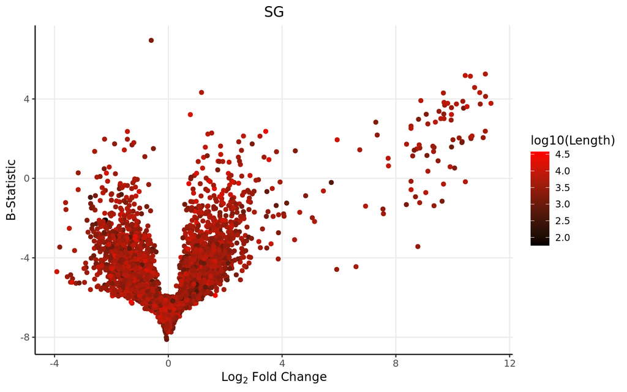

```r
DEGenes$Gene <- row.names(DEGenes)
colnames(genelength) <- c("Length","Gene")
DEGenes <- merge(DEGenes, genelength, by="Gene")

ggplot(data=DEGenes,
                 aes(x=logFC,
                     y=  B)) +
  geom_point(aes(color=log10(Length)))+
  theme_bw() +
  theme(axis.line = element_line(colour = "black"),
        panel.grid.minor = element_blank(),
        panel.border = element_blank(),
        panel.background = element_blank()) +
  ggtitle("SG")+ xlab(expression(Log[2] ~ Fold ~ Change)) + ylab("B-Statistic") +
  theme(plot.title = element_text(hjust = 0.5))  +
  scale_colour_gradient(low = "black", high = "red")+ theme(text=element_text(family = "Quicksand"))
```

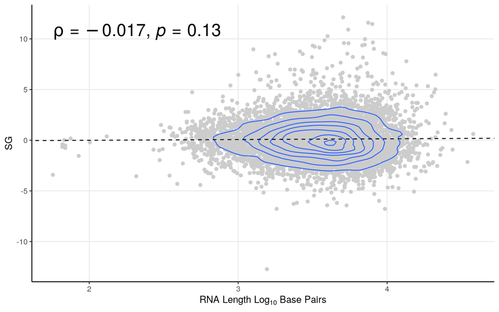

```r
smooth.SG <- lm(t~log10(Length), DEGenes)
liner.SG <- rstandard(smooth.SG)
DEGenes <-cbind(DEGenes, liner.SG)
colnames(DEGenes)[9] <- "Residuals"
row.names(DEGenes) <- DEGenes$Gene
linemarkers <- as.data.frame(DEGenes[abs(DEGenes$Residuals)>4,])

# Calculate the Spearman correlation coefficient
spearman_corr <- cor(DEGenes$t, log10(DEGenes$Length), method = "spearman")



ggplot(DEGenes, aes(y=t, x=log10(Length))) + geom_point(color="#CCCCCC", alpha=1) +   theme_bw()+ geom_density_2d()+
 ylab("SG") + xlab(expression(RNA ~ Length ~ Log[10] ~ Base ~ Pairs)) +
  theme(axis.line = element_line(colour = "black"),
        panel.grid.minor = element_blank(),
        panel.border = element_blank(),
        panel.background = element_blank()) +
  theme(plot.title = element_text(hjust = 0.5))  +
  geom_abline(slope=smooth.SG$coefficients[2], intercept = smooth.SG$coefficients[1], linetype = "dashed")+ stat_cor(method = "spearman", cor.coef.name = "rho",size=7)
```

No lenght bias

## Expression Graphs (Extra QC)

As an added control, lets plot these genes in regard to their expression, and contamination.

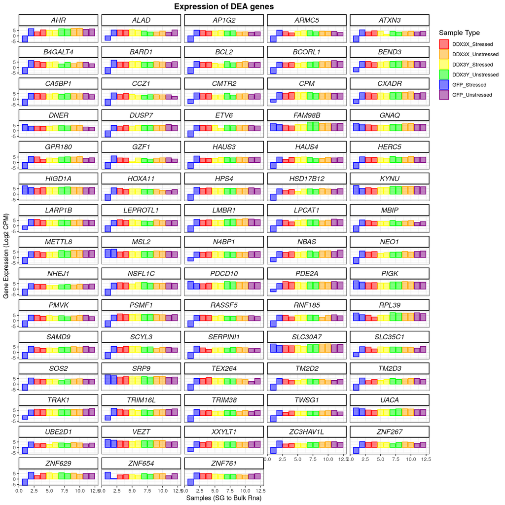

```r
upmarkers <- as.data.frame(DEGenes[DEGenes$logFC>8 & DEGenes$adj.P.Val<0.05,] )
downmarkers <- as.data.frame(DEGenes[DEGenes$logFC< -2 & DEGenes$adj.P.Val<0.05,] )
finagenes <- rbind(upmarkers, downmarkers)

dfforexpression <- dfforpca
samplecodes <- data.frame(samples=row.names(dfforexpression), purity=c(1:12))
sampletype <- data.frame(samples=row.names(dfforexpression), sampletype=fordescriptive)
dfforexpression <- t(dfforexpression)
genesforexp <- dfforexpression[row.names(dfforexpression)%in%row.names(finagenes),]
genesforexp <- reshape2::melt(genesforexp)
colnames(genesforexp) <- c("Gene", "samples", "expression")
genesforexp <- merge(genesforexp, samplecodes, by="samples")
genesforexp <- merge(genesforexp, sampletype, by="samples")
genesforexp <- genesforexp[,-1]
genesforexp[,2] <- as.numeric(genesforexp[,2])
genesforexp[,1] <- as.character(genesforexp[,1])
genesforexp <- genesforexp[order(genesforexp$Gene),]


winnyplot <- ggplot(genesforexp, aes(x=purity, y=expression, fill=sampletype, colour=sampletype)) + geom_bar(position="dodge", stat="identity", alpha=0.5) + facet_wrap(.~ Gene, ncol=5)
winnyplot <- winnyplot + scale_fill_manual(name = "Sample Type", values = c("#FF0000", "#FFA500", "#FFFF00", "#00FF00", "#0000FF", "#800080", "grey")) + scale_colour_manual(name = "Sample Type", values = c("#FF0000", "#FFA500", "#FFFF00", "#00FF00", "#0000FF", "#800080", "grey"))
winnyplot <- winnyplot + theme_bw() + xlab("Samples (SG to Bulk Rna)") + ylab("Gene Expression (Log2 CPM)") + theme(
      strip.text.x = element_text(
        size = 12, face="italic"
        )) +
 theme(
   strip.background = element_rect(
     color="black", fill="#FFFFFF", size=1, linetype="solid"
     )
   ) + theme(
    #legend.position = c(.95, .40),
    legend.justification = c("right", "top"),
    legend.box.just = "right",
    ) + theme(legend.title = element_text(size = 12)) + ggtitle("Expression of DEA genes") + theme(plot.title = element_text(hjust = 0.5, size=14, face="bold"))
winnyplot
```

## GSEA

Now that we have our genes of interest, it would also be interesting to see what are the **altered gene sets** between upregulated and downregulated transcripts from the above comparison. Therefore, lets perform a *Gene Set Enrichment Analysis*

```r
#for all genes
DEGenes <- DEGenes[order(DEGenes[,4]),]
gseatool <- DEGenes[,4]
gseatool <- as.data.frame(gseatool)
colnames(gseatool)[1] <- "t"
gseatool[,2] <- DEGenes$Gene
colnames(gseatool)[2] <- "Symbol"
gseatool <- gseatool[,c(2,1)]

vectorranks <- gseatool$t
names(vectorranks) <- gseatool$Symbol


#to load our pathways
hallmarks.gs <- msigdbr(species = "Homo sapiens", collection =  "H")

hallmarks.gsets <- hallmarks.gs %>% split(x = .$gene_symbol, f = .$gs_name)

for (set in names(hallmarks.gsets)){
  hallmarks.gsets[[set]] <- toupper(hallmarks.gsets[[set]])
}

hallmarks.res <- fgsea(pathways = hallmarks.gsets,
                       stats = vectorranks)
hallmarks.res.tidy <- hallmarks.res %>%
  as_tibble() %>%
  arrange(desc(NES))

hallmarks.res.tidy %>%
  dplyr::select(-leadingEdge, -ES) %>%
  arrange(padj)
```

```
## # A tibble: 50 × 6
##    pathway                                      pval    padj log2err   NES  size
##    <chr>                                       <dbl>   <dbl>   <dbl> <dbl> <int>
##  1 HALLMARK_APICAL_JUNCTION                  6.99e-5 0.00175   0.538  1.94    78
##  2 HALLMARK_MYC_TARGETS_V1                   6.86e-5 0.00175   0.538 -1.65   185
##  3 HALLMARK_MITOTIC_SPINDLE                  2.11e-3 0.0351    0.432  1.58   164
##  4 HALLMARK_IL2_STAT5_SIGNALING              3.19e-3 0.0399    0.432  1.67    82
##  5 HALLMARK_MYOGENESIS                       8.44e-3 0.0844    0.381  1.62    62
##  6 HALLMARK_ESTROGEN_RESPONSE_EARLY          1.11e-2 0.0923    0.381  1.51   103
##  7 HALLMARK_HYPOXIA                          1.49e-2 0.107     0.381  1.48   105
##  8 HALLMARK_KRAS_SIGNALING_DN                2.34e-2 0.130     0.352  1.58    24
##  9 HALLMARK_XENOBIOTIC_METABOLISM            2.19e-2 0.130     0.352  1.51    79
## 10 HALLMARK_REACTIVE_OXYGEN_SPECIES_PATHWAY  5.11e-2 0.246     0.253  1.46    36
## # ℹ 40 more rows
```

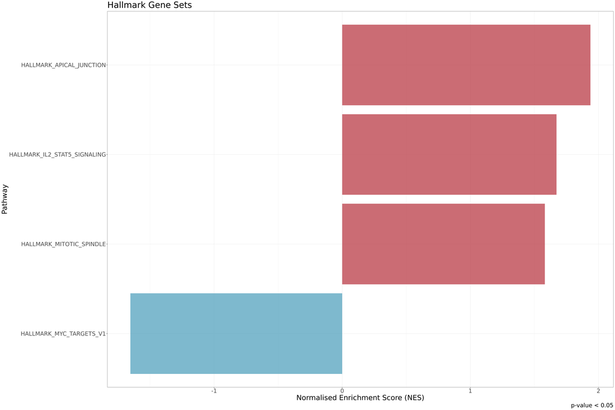

```r
hallmark.sg.t <- hallmarks.res.tidy[,c(1,6)]
hallmark.sg.t <- as.data.frame(hallmark.sg.t)

#this small part is generic
thresh <- 0.05

#this one is no longer generic
data_to_plot <- hallmarks.res.tidy %>% filter(padj < thresh)

statvec <- c()
for (i in 1:nrow(data_to_plot)){
  if (data_to_plot[i,6] > 0){
    status <- "Upregulated"
  }
 else {
   status <- "Downregulated"
 }
statvec <- c(statvec, status)
}

data_to_plot$Status <- statvec

##-----HALMARK-----
gsea_plot_hall <- ggplot(data_to_plot, aes(reorder(pathway, NES), NES)) +
  geom_col(aes(fill= Status), alpha=0.75) + scale_fill_manual(values = c("#53A2BE","#BA3B46"), name = "Regulation Status", labels = c("Downregulated", "Upregulated"), breaks = c("Downregulated", "Upregulated")) +
  coord_flip() +
  labs(x="Pathway", y="Normalised Enrichment Score (NES)",
       title= "Hallmark Gene Sets",
       caption = paste0("p-value < ", thresh)) + theme(plot.title = element_text(hjust = 1)) +
  theme_bw() + theme(text=element_text(family = "Quicksand")) + theme(legend.position = "none")

gsea_plot_hall+
  theme(text=element_text(size=25,  family="Arial MS"))
```

[^1]: Disease Transcriptomics Group, Gulbenkian Institute of Molecular Medicine